# Response of Basal Area Growth of Scots Pine to Thinning: A Longitudinal Analysis of Tree-Specific Series Using a Nonlinear Mixed-Effects Model | Forest Science | Oxford Academic

### Parameter estimates for the model of thinning response of ring basal area (Equations 5–7).

Table 4.

Parameter estimates for the model of thinning response of ring basal area (Equations 5–7).

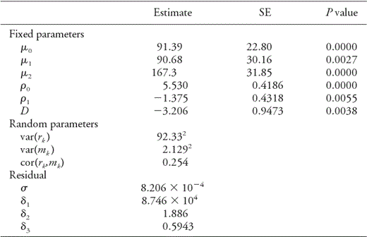

[Open in new tab](https://academic.oup.com/view-large/107236437)

[figure not shown]

[Open in new tab](https://academic.oup.com/view-large/107236437)

The fixed part of the model showed only the dynamics of a typical tree-level thinning response. At the individual tree level, there was still much variation that was not explained by the thinning treatment or tree diameter. The estimated tree effects showed an SD of 92 mm<sup>2</sup>/year in the maximum thinning response and of 2 years in the reaction time. [Figure 4](https://academic.oup.com/forestscience/article/60/4/636/4583784) shows the tree-specific fitted curves for 25 randomly selected sample trees.

Figure 4.

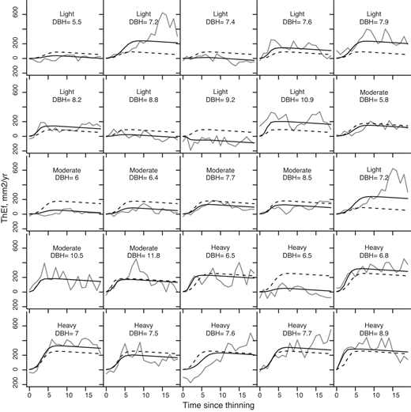

[Open in new tab](https://academic.oup.com/view-large/figure/107236439/for0021426780004.tif)Download slide

[figure not shown]

[Open in new tab](https://academic.oup.com/view-large/figure/107236439/for0021426780004.tif)Download slide

The residuals of the model increased with respect to the predicted thinning response, but that variation was successfully modeled using the applied variance function so that the graph of standardized residuals (not shown) did not show signs of heteroscedasticity. In addition, the residuals had a strong temporal autocorrelation of 0.59, which was successfully modeled using the AR(1) process.

## Discussion

### Modeling Approach

A drawback of the nonlinear modeling approach was the need to do the modeling in two steps. A natural next step in our modeling work is to write the models of the two modeling steps in a single model with a linear component for the unthinned growth and an additive nonlinear thinning response. Such a model would have made better use of the data than the two-step procedure. However, such analysis would have required a nonlinear mixed-effects model with crossed random effects. Unfortunately, the widely used software programs (e.g., R, SAS, and SPSS) do not currently provide tools for fitting such models.

An alternative to the nonlinear model for the thinning response is a linear model with transformations in the predictors that allow the shape shown in [Figure 1](https://academic.oup.com/forestscience/article/60/4/636/4583784). For example, a high-order polynomial or a similar spline as in model 1 (see Equation 2) could have been used as well. Such a model could have provided a fit as good as that for the nonlinear model of this study. The tests on the model should also have been even more reliable because they do not need linear approximations for the likelihood as do the tests for the nonlinear model. Furthermore, a linear mixed-effects model for the thinning response would have allowed pooling of the two models into one single model. However, the parameters of the linear model would not have had clear interpretations. Our main target was to better understand and formally test how stand density and tree size affect the thinning response of single trees. Therefore, even though the linear one-step model could have provided the benefits described above, the nonlinear modeling was a better tool for this study.

The decrease in the thinning response after the reaction time was modeled in our work by a linear trend, starting 7 years after the reaction time. The starting point was given as fixed because the decreasing trend was so weak in our data that a two-parameter model for it showed problems in model fitting. We also tried other fixed starting points, as well as starting right after the reaction time. The other fixed starting points did not make a significant difference in our model, whereas using reaction time as the starting point mixed the interpretation of this parameter both as the reaction time and as the starting time of the gradual decrease of the response.

The assumed linear decrease for the thinning response was sufficient for the 18-year follow-up period of our data, but it is naturally not sufficient for longer follow-up periods because it allows the response to become negative. Some trials on a more complex form of this component were also done (e.g., some asymptotically decreasing functions), but they were unsuccessful because of a follow-up time that was too short compared with the time needed for the full disappearance of the thinning response. In fact, we hypothesize that the thinning response of individual trees could remain positive in our thinning plots until canopy closure occurs again, revealing increased competition between neighboring trees for growth resources (light, water, and nutrients).

This work demonstrated that the mixed-effects models may be justified for two different reasons, i.e., prediction and inference. In the first step of the analysis, the linear mixed-effects model was fitted to predict the undisturbed growth of the trees in the thinned plots. This approach allowed prediction of the undisturbed growth that is based on only a small number of pretreatment measurements and is unbiased over the calendar years and trees. On the other hand, a sophisticated model for residual autocorrelation was not necessary because the inference on the parameter estimates was not so important. In the second step, the main motivation for mixed-effects model was inference: the random effects together with the variance function and the model for residual autocorrelation parameterized the structure of the data in such a way that the inference on the fixed parameters was reliable. On the other hand, predictions of random effects of this model were not of as much interest as in the first step of the analysis.

### Dynamics of The Thinning Response

The linear mixed-effects model with crossed effects could explain 86% of the total variance in the logarithmic basal area growth of Scots pine trees in the unthinned sample plots (i.e., the control treatment for the whole period and thinned plots before the thinning). Of the explained variation, tree-to-tree variation contributed the major proportion (68% of the total variation), followed by the age trend (13%) and year-to-year variation (5%). However, because the sample plots were roughly of the same age, the age trend and year effects may have been somewhat mixed. Had the trees been younger, the age trend would have played a much more important role because the age-driven growth trend is most variable at young ages (e.g., [Gort et al. 2011](https://academic.oup.com/forestscience/article/60/4/636/4583784)).

As expected by the previous studies (e.g., [Valinger 1992](https://academic.oup.com/forestscience/article/60/4/636/4583784), [Ruha and Varmola 1997](https://academic.oup.com/forestscience/article/60/4/636/4583784), [Hasenauer et al. 1997](https://academic.oup.com/forestscience/article/60/4/636/4583784), [Pukkala et al. 1998](https://academic.oup.com/forestscience/article/60/4/636/4583784), [Montero et al. 2001](https://academic.oup.com/forestscience/article/60/4/636/4583784), [Peltola et al. 2002](https://academic.oup.com/forestscience/article/60/4/636/4583784), [2007](https://academic.oup.com/forestscience/article/60/4/636/4583784), [Mäkinen et al. 2005](https://academic.oup.com/forestscience/article/60/4/636/4583784)), the thinning intensity and tree size increased the average thinning responses over the whole 18-year postthinning period ([Table 2](https://academic.oup.com/forestscience/article/60/4/636/4583784)). However, the longitudinal analysis of the tree-specific series of thinning responses revealed the different mechanisms behind the thinning dynamics. The thinning intensity mostly affected the maximum thinning response, whereas tree size mostly affected the reaction time. Although visually detectable relationships were also observed between tree size and maximum thinning response and between treatment and reaction time ([Figure 3](https://academic.oup.com/forestscience/article/60/4/636/4583784)), these relationships were not statistically significant in our final model (*P* > 0.05). In addition, there was much remaining variation in the tree-level responses to thinning that could not be explained by thinning treatments or tree size.

An increase in the maximum thinning response to thinning intensity can be naturally explained by the reduced competition for growth resources between the remaining trees in a stand after thinning. Similarly, the effect of tree size on reaction time can be explained by the time needed for a tree to increase its crown (needle) area, affecting the growth rate of a tree ([Medhurst and Beadle 2001](https://academic.oup.com/forestscience/article/60/4/636/4583784), [2005](https://academic.oup.com/forestscience/article/60/4/636/4583784)). In our study, the reaction time was clearly shorter for larger trees than for smaller ones, ranging from 3 to 8 years. Scots pine usually has three to four needle age classes in southern Finland ([Sarvas 1961](https://academic.oup.com/forestscience/article/60/4/636/4583784)). Therefore, the reaction time for the largest trees is roughly as long as the time needed to renew all the needle classes after thinning.

Our analysis confirmed and quantified the slow response of basal area growth to thinning in coniferous trees. Similar results have been graphically reported before (e.g., [Jonsson 1995](https://academic.oup.com/forestscience/article/60/4/636/4583784), [Tasissa and Burkhart 1997](https://academic.oup.com/forestscience/article/60/4/636/4583784), [Valinger et al. 2000](https://academic.oup.com/forestscience/article/60/4/636/4583784)) but without explicit quantification and statistical testing. After the reaction time, only a slight decrease in the thinning response over the 18-year postthinning period was observed in our study. Some previous studies (e.g., [Jonsson 1995](https://academic.oup.com/forestscience/article/60/4/636/4583784), [Ikonen et al. 2006](https://academic.oup.com/forestscience/article/60/4/636/4583784)) have reported a larger decrease, but this may be an artifact explained by the fact that the analysis was based on radial growth (ring width). Because of the increase in circumference, similar basal area growth implies larger diameter growth for small trees than for large trees and vice versa. In principle, our results showing only a slow decrease in the thinning response over time is logical, as one could expect that the thinning response, especially in lower parts of the bole, will last until the free crown space is completely fulfilled.

Our results indicate that most trees can eventually reach rather similar thinning responses on basal area growth over the 18-year study period, even though it takes a longer time for the smallest trees. Therefore, the decreased total growth rate after thinning should last longer after thinning from above than after thinning from below. However, maximum thinning responses after the reaction time should not show large differences.

## Conclusions

This work demonstrated the good applicability of the linear and nonlinear mixed-effects modeling approach for analyses on the response of individual tree growth on a treatment. Our approach could be applied in other circumstances and for other treatments, too. The empirical results showed that the maximum thinning response was affected by thinning intensity, whereas the reaction time was affected significantly by the size of the tree before thinning. The thinning response also decreased slowly after the maximum response was reached. The observed mechanism on the effects of tree size and thinning intensity on the tree-level response might generalize to other locations and tree species, too. However, because our data represented only one thinning experiment and some very suppressed sample trees (mainly from control and light thinning treatments) had to be removed from the analysis because of undetectable narrow rings, the numerical estimates of the thinning effect should not be generalized.

Acknowledgments: We thank Jarmo Pennala and Marja Kuskelin from the University of Eastern Finland for harvesting the sample trees in our thinning trial and Prof. Timo Pukkala for helpful discussions on the topic of the article. Jarmo Pennala is also thanked for assistance with X-ray measurements. The support provided by the University of Eastern Finland, School of Forest Sciences, is gratefully acknowledged.

## Literature Cited

Assmann

E.

1970

.

*The principles of forest yield study*

Pergamon Press

,

Oxford, UK

.

506

p.

[Google Scholar](https://scholar.google.com/scholar_lookup?title=The%20principles%20of%20forest%20yield%20study&author=E.%20Assmann&publication_year=1970&book=The%20principles%20of%20forest%20yield%20study)

Bergsten

U.

Lindeberg

J.

Rindby

A.

Evans

R.

.

2001

.

Batch measurements of wood density on intact or prepared drill cores using x-ray microdensitometry

.

*Wood Sci. Technol*

.

35

:

435

–

452

.

Google Scholar

[Crossref](http://dx.doi.org/10.1007/s002260100106)

Burkhar

H.E.

Tomé

M.

.

2012

.

*Modeling forest trees and stands*

.

Springer

,

Dordrecht, The Netherlands

.

457

p.

[Google Scholar](https://scholar.google.com/scholar_lookup?title=Modeling%20forest%20trees%20and%20stands&author=H.E.%20Burkhar&author=M.%20Tom%C3%A9&publication_year=2012&book=Modeling%20forest%20trees%20and%20stands)

[Crossref](http://dx.doi.org/10.1007/978-90-481-3170-9)

Cook

E.R.

Kairiukstis

L.A.

(eds.).

1990

.

*Methods of dendrochronology*

.

Kluwer Academic Publishers

,

Dordrecht, The Netherlands

.

394

p.

[Google Scholar](https://scholar.google.com/scholar_lookup?title=Methods%20of%20dendrochronology&author=E.R.%20Cook&author=L.A.%20Kairiukstis&publication_year=1990&book=Methods%20of%20dendrochronology)

[Crossref](http://dx.doi.org/10.1007/978-94-015-7879-0)

Gort

J.

Mehtätalo

L.

Peltola

H.

Zubizarreta-Gerendiain

A.

Pulkkinen

P.

Venäläinen

A.

.

2011

.

Effects of spacing and genetic entry on radial growth and ring density development in Scots pine (*Pinus sylvestris* L.)

.

*Ann. For. Sci*

.

68

(

7

):

1233

–

1243

.

Google Scholar

[Crossref](http://dx.doi.org/10.1007/s13595-011-0117-8)

Harrell

F.E.

2001

.

*Regression modeling strategies with applications to linear models, logistic regression, and survival analysis*

.

Springer

,

Berlin, Germany

.

568

p.

Google Scholar

Hasenauer

H.

Burkhart

H.E.

Amateis

R.L.

.

1997

.

Basal area development in thinned and unthinned loblolly pine plantations

.

*Can. J. For. Res*

.

27

(

2

):

265

–

271

.

Google Scholar

[Crossref](http://dx.doi.org/10.1139/x96-163)

Ikonen

V.-P.

Kellomäki

S.

Väisänen

H.

Peltola

H.

.

2006

.

Modelling the distribution of diameter growth along the stem in Scots pine

.

*Trees*

20

:

391

–

402

.

Google Scholar

[Crossref](http://dx.doi.org/10.1007/s00468-006-0053-7)

Jonsson

B.

1995

.

Thinning response functions for single trees of *Pinus sylvestris* L. and *Picea abies* (L.) Karst

.

*Scand. J. For. Res*

.

10

:

353

–

369

.

Google Scholar

[Crossref](http://dx.doi.org/10.1080/02827589509382902)

Lappi

J.

Mehtätalo

L.

Korhonen

K.T.

.

2006

.

Generalizing sample tree information

. P.

83

–

106

in

*Forest inventory—Methodology and applications*

,

Kangas

A.

Maltamo

M.

(eds).

Springer

,

Berlin, Germany

.

Google Scholar

[Crossref](http://dx.doi.org/10.1007/1-4020-4381-3)

Lessard

V.C.

McRoberts

R.E.

Holdaway

M.R.

.

2001

.

Diameter growth models using Minnesota forest inventory and analysis data

.

*For. Sci*

.

47

(

3

):

301

–

310

.

Google Scholar

Medhurst

J.L.

Beadle

C.L.

.

2001

.

Crown structure and leaf area index development in thinned and unthinned *Eucalyptus nitens* plantations

.

*Tree Physiol*

.

21

:

989

–

999

.

Google Scholar

[Crossref](http://dx.doi.org/10.1093/treephys/21.12-13.989)

[PubMed](http://www.ncbi.nlm.nih.gov/pubmed/11498346)

Medhurst

J.L.

Beadle

C.L.

.

2005

.

Photosynthetic capacity and foliar nitrogen distribution in *Eucalyptus nitens* is altered by high-intensity thinning

.

*Tree Physiol*

.

25

:

981

–

991

.

Google Scholar

[Crossref](http://dx.doi.org/10.1093/treephys/25.8.981)

[PubMed](http://www.ncbi.nlm.nih.gov/pubmed/15929929)

Monseurd

R.A.

1986

.

Time-series analyses of tree-ring chronologies

.

*For. Sci*

.

32

(

2

):

349

–

372

.

[Google Scholar](https://scholar.google.com/scholar_lookup?title=Time-series%20analyses%20of%20tree-ring%20chronologies&author=R.A.%20Monseurd&publication_year=1986&journal=For.%20Sci&volume=32&pages=349-372)

Montero

G.

Cañellas

I.

Ortega

C.

Del Rio

M.

.

2001

.

Results from a thinning experiment in a Scots pine (*Pinus sylvestris* L.) natural regeneration stand in the Sistema Ibérico Mountain Range (Spain)

.

*For. Ecol. Manage*

.

145

:

151

–

161

.

Google Scholar

Crossref

Mäkinen

H.

Isomäki

A.

.

2004a

.

Thinning intensity and growth of Scots pine stands in Finland

.

*For. Ecol. Manage*

.

201

:

311

–

325

.

Google Scholar

[Crossref](http://dx.doi.org/10.1016/j.foreco.2004.07.016)

Mäkinen

H.

Isomäki

A.

.

2004b

.

Thinning intensity and long term changes in increment and stem form of Scots pine trees

.

*For. Ecol. Manage*

.

203

:

21

–

34

.

Google Scholar

[Crossref](http://dx.doi.org/10.1016/j.foreco.2004.07.028)

Mäkinen

H.

Hynynen

J.

Isomäki

A.

.

2005

.

Intensive management of Scots pine stands in southern Finland: First empirical results and simulated further development

.

*For. Ecol. Manage*

.

215

:

37

–

50

.

Google Scholar

[Crossref](http://dx.doi.org/10.1016/j.foreco.2005.03.069)

Peltola

H.

Miina

J.

Rouvinen

I.

Kellomäki

S.

.

2002

.

Effect of early thinning on the diameter growth distribution along the stem of Scots pine

.

*Silva Fenn*

.

36

(

4

):

813

–

825

.

Google Scholar

[Crossref](http://dx.doi.org/10.14214/sf.523)

Peltola

H.

Kilpeläinen

A.

Sauvala

K.

Räisänen

T.

Ikonen

V.-P.

.

2007

.

Effects of early thinning regime and tree status on the radial growth and wood density of Scots pine

.

*Silva Fenn*

.

41

(

3

):

489

–

505

.

Google Scholar

[Crossref](http://dx.doi.org/10.14214/sf.285)

Pinheiro

J.C.

Bates

D.M.

.

2000

.

*Mixed-effects models in S and S-PLUS. Statistics and computing series*

.

Springer-Verlag

,

New York

.

528

p.

Google Scholar

Pukkala

T.

Miina

J.

Kellomäki

S.

.

1998

.

Response to different thinning intensities in young Pinus sylvestris

.

*Scand. J. For. Res*

.

13

:

141

–

150

.

Google Scholar

[Crossref](http://dx.doi.org/10.1080/02827589809382970)

Pukkala

T.

Miina

J.

Palahi

M.

.

2002

.

Thinning response and thinning bias in a young Scots pine stand

.

*Silva Fenn*

.

36

(

4

):

827

–

840

.

Google Scholar

[Crossref](http://dx.doi.org/10.14214/sf.524)

R Development Core Team

.

2010

.

*R: A language and environment for statistical computing*

.

R Foundation for Statistical Computing

,

Vienna, Austria

.

Google Scholar

Ruha

T.

Varmola

M.

.

1997

.

Precommercial thinning in naturally regenerated Scots pine stands in Northern Finland

.

*Silva Fenn*

.

31

(

2

):

401

–

415

.

Google Scholar

Sarvas

R.

1961

.

*Conifers*

.

WSOY

,

Helsinki, Finland (in Finnish)

.

531

p.

[Google Scholar](https://scholar.google.com/scholar_lookup?title=Conifers&author=R.%20Sarvas&publication_year=1961&book=Conifers)

Tasissa

G.

Burkhart

H.E.

.

1997

.

Modelling thinning effects on ring width distribution in loblolly pine (*Pinus taeda*)

.

*Can. J. For. Res*

.

27

:

1291

–

1301

.

Google Scholar

[Crossref](http://dx.doi.org/10.1139/x97-092)

Valinger

E.

1992

.

Effects of thinning and nitrogen fertilization on stem growth and stem form of *Pinus sylvestris* trees

.

*Scand. J. For. Res*

.

7

:

219

–

228

.

Google Scholar

[Crossref](http://dx.doi.org/10.1080/02827589209382714)

Valinger

E.

Elfving

B.

Mörling

T.

.

2000

.

Twelve-year growth response of Scots pine to thinning and nitrogen fertilization

.

*For. Ecol. Manage*

.

134

:

45

–

53

.

Google Scholar

Crossref

Van Deusen

P.C.

1989

.

A model-based approach to tree ring analysis

.

*Biometrics*

45

:

763

–

779

.

[Google Scholar](https://scholar.google.com/scholar_lookup?title=A%20model-based%20approach%20to%20tree%20ring%20analysis&author=P.C.%20Van%20Deusen&publication_year=1989&journal=Biometrics&volume=45&pages=763-779)

[Crossref](http://dx.doi.org/10.2307/2531682)

Wykoff

W.R.

1990

.

A basal area increment model for individual conifers in the Northern Rocky Mountains

.

*For. Sci*

.

36

(

4

):

1077

–

1104

.

Google Scholar

Copyright © 2014 Society of American Foresters

[figure not shown]